# Scoring the SF-36

Dom Grisafe

12/11/2018

# 36-Item Short Form Health Survey (SF-36)

The [SF-36](https://www.rand.org/health/surveys_tools/mos/36-item-short-form/survey-instrument.html), produced by RAND, is one of the most common instruments for measuring quality of life. It is frustrating to learn to manually score the SF-36, when it is clear that numerous researchers must be recoding the survey each time. This is my attempt to automate the administration and scoring of the SF-36.

## Google Form Version of SF-36

Here is a [folder](https://drive.google.com/drive/folders/1W7OvdZls7Y52vpiyQKPgF1YVjpXtSNPd?usp=sharing) containing the Google Form version of the SF-36 as well as the corresponding Google Sheet containing dummy responses. Google does not allow public sharing of a Form, and this will unfortunately have to be recreated by others manually.

Google forms eliminate data entry steps, make the data collection process more repeatable, and can save money on unnecessary administrative costs. Google forms are not commonly used in academia despite [commentaries encouraging the use of Google Forms in health and social sciences](https://www.ncbi.nlm.nih.gov/pmc/articles/PMC3884902/).

## Loading the SF-36 from Google Form to Excel to R

Once data has been collected using the Google Form, download the file as an excel document. This can then be loaded into R using the [readxl](https://www.rdocumentation.org/packages/readxl/versions/0.1.1) package. This is dummy data made for the purposes of explanation, which was placed in the same folder as the R Markdown file.

## Recoding the SF-36

RAND provides [Scoring Instructions](https://www.rand.org/health/surveys_tools/mos/36-item-short-form/scoring.html). Ron Hays has published a [SAS program](https://www.rand.org/pubs/drafts/DRU1437.html) to score the SF-36 automatically; this [Word version](https://cours.etsmtl.ca/gts813/documents/sf36_scoring_system.doc) was used as a template for scoring the survey in R. All variables should be renamed and certain items must be reversed. See the accomanying R Markdown file for details.

## SF-36 8 Subscale Scores

The 8 subscales of the SF-36 are calculated by taking the means of specific groups of items. Details of item groupings are available in the table on page 2 of [SF-36 scoring instructions](http://www.alswh.org.au/images/content/pdf/InfoData/Data_Dictionary_Supplement/DDSSection2SF36.pdf) by the [Australian Longitudinal Study on Women’s Health](https://www.alswh.org.au/).

```
## [1] "8 Subscale Scores of the SF-36, raw (i.e., not standardized)"
```

```
## # A tibble: 8 x 6
##   Scale                Abbreviation weight  mean stdErr stdDev
##   <chr>                <chr>         <dbl> <dbl>  <dbl>  <dbl>
## 1 Physical Functioning PF           0.476   44     3.67    8.2
## 2 Role Physical        RP           0.190   35    12.7    28.5
## 3 Bodily Pain          BP           0.0952  55.5   9.33   20.9
## 4 General Health       GH           0.238   53     8.60   19.2
## 5 Vitality             VT           0.286   51     9.67   21.6
## 6 Social Functioning   SF           0.143   47.5   6.12   13.7
## 7 Role Emotional       RE           0.214   40     6.67   14.9
## 8 Mental Health        MH           0.357   48     6.20   13.9
```

## Comparing SF-36 Sample Scores to US Population

Standardize the 8 subscales of the SF-36 to the [general US population](https://www.ncbi.nlm.nih.gov/pmc/articles/PMC3582698/).

```
## [1] "8 subscales of the SF-36 Standardized to General US Population"
```

```
## # A tibble: 8 x 6
##   Scale                Abbreviation weight  mean stdErr stdDev
##   <chr>                <chr>         <dbl> <dbl>  <dbl>  <dbl>
## 1 Physical Functioning stdPF        0.476   -0.5  0.254    0.6
## 2 Role Physical        stdRP        0.190   -1    0.867    1.9
## 3 Bodily Pain          stdBP        0.0952   0.3  0.573    1.3
## 4 General Health       stdGH        0.238    0.2  0.510    1.1
## 5 Vitality             stdVT        0.286   -0.2  0.630    1.4
## 6 Social Functioning   stdSF        0.143   -0.3  0.440    1
## 7 Role Emotional       stdRE        0.214   -0.9  0.508    1.1
## 8 Mental Health        stdMH        0.357   -0.5  0.467    1
```

## Calculating Standardized Component Scores: Physical and Mental Composites

The [Australian Longitudinal Study on Women’s Health](https://www.alswh.org.au/) provides [instructions on how to calculate the physical and mental composite scores](http://www.alswh.org.au/images/content/pdf/InfoData/Data_Dictionary_Supplement/DDSSection2SF36.pdf) of the SF-36 when all of the 8 subscales are available.

```
## [1] "Physical and Mental Composite Scores of the SF-36 Standardized to General US Population"
```

```
## # A tibble: 10 x 5
##    Scale                    Abbreviation  Mean    SE    SD
##    <chr>                    <chr>        <dbl> <dbl> <dbl>
##  1 Physical Functioning     PF            44    3.67   8.2
##  2 Role Physical            RP            35   12.7   28.5
##  3 Bodily Pain              BP            55.5  9.33  20.9
##  4 General Health           GH            53    8.60  19.2
##  5 Vitality                 VT            51    9.67  21.6
##  6 Social Functioning       SF            47.5  6.12  13.7
##  7 Role Emotional           RE            40    6.67  14.9
##  8 Mental Health            MH            48    6.20  13.9
##  9 Physical Composite Score PCS           46.6  1.64   3.7
## 10 Mental Composite Score   MCS           45.5  1.69   3.8
```

## Export the 8 Subscales, Standardized Subscales, and Composite Scores of the SF-36 to Excel

An excel file will be produced enumerating the raw 8 scale scores as well as the PCS and MCS composite scores, standardized to the general US population.

```r
# export to excel
sampleUSCompare %>% write.xlsx("!SF36_CompositeScores.xlsx", sheetName = "Mean Subscales & Composites")
std_subScale8 %>% select(-starts_with("std")) %>% write.xlsx("!SF36_CompositeScores.xlsx", sheetName="Individual Data", append=TRUE)
```

## Distributions of Physical and Mental Composite Scores

Look at the distributions of PCS and MCS in the sample.

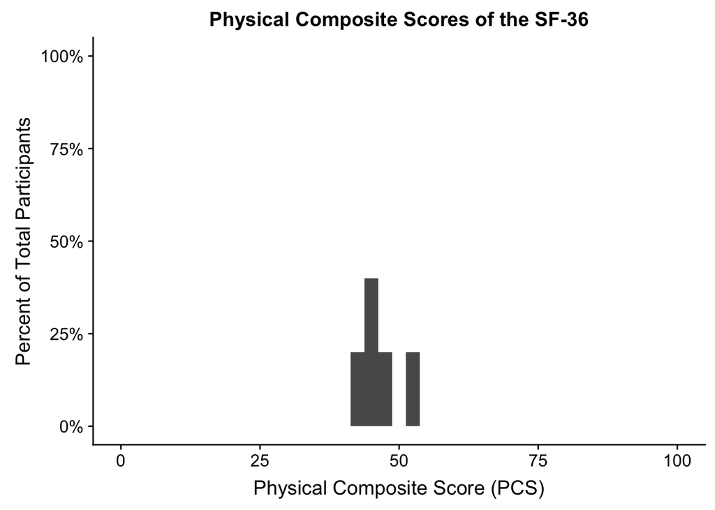

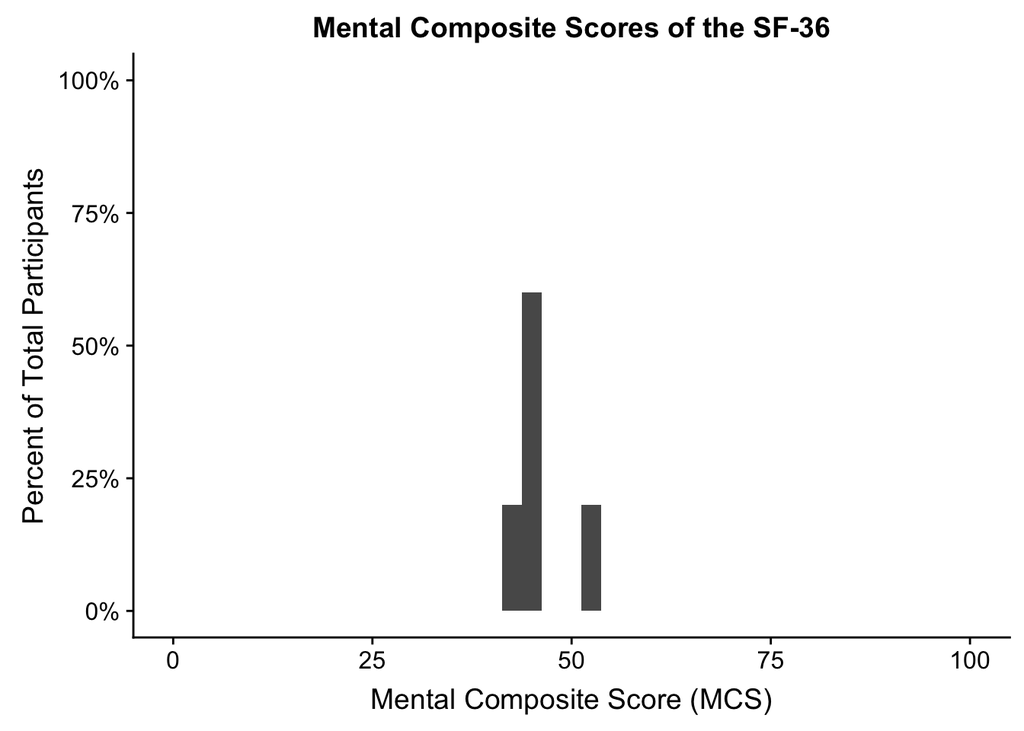

## Visually Compare the SF-36 of the Sample and General US Population

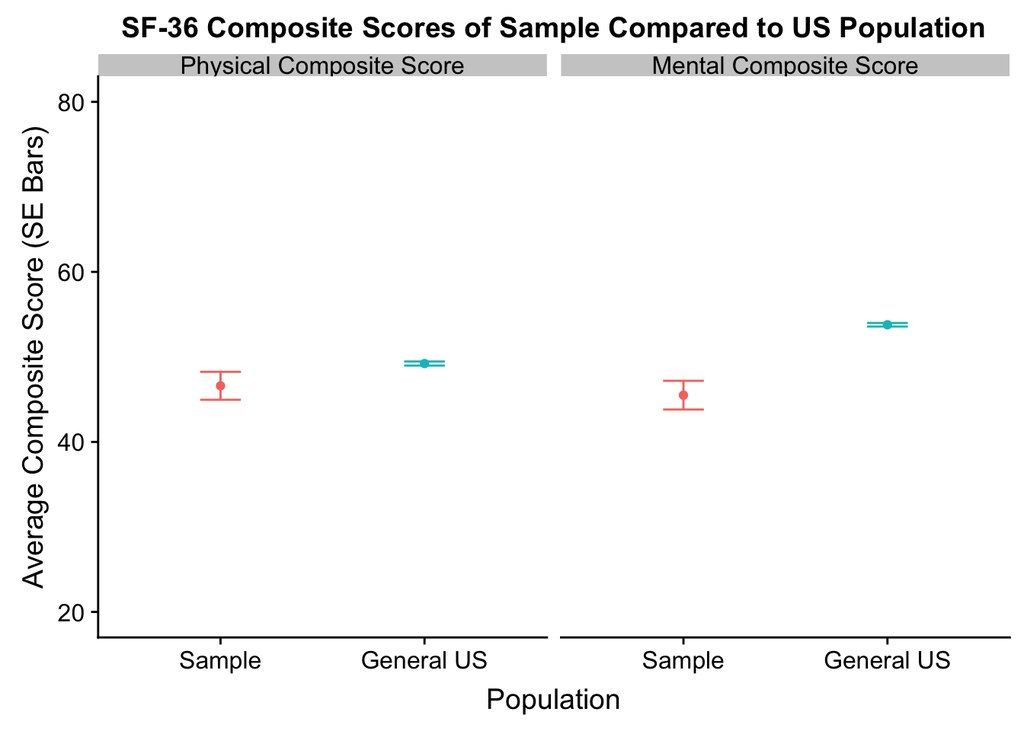

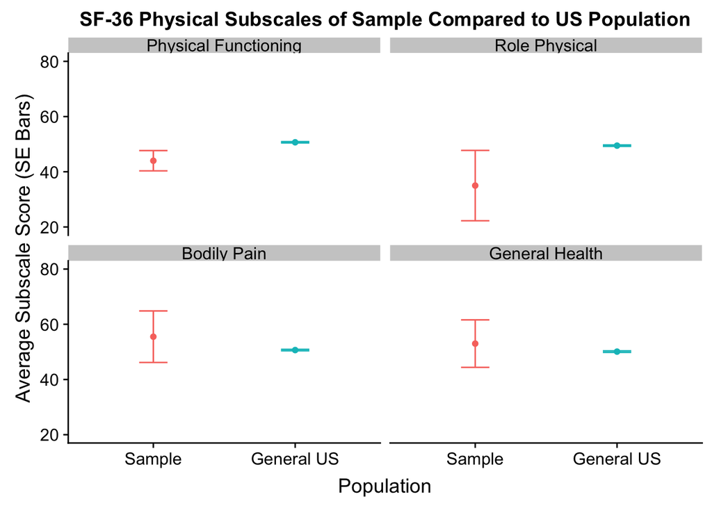

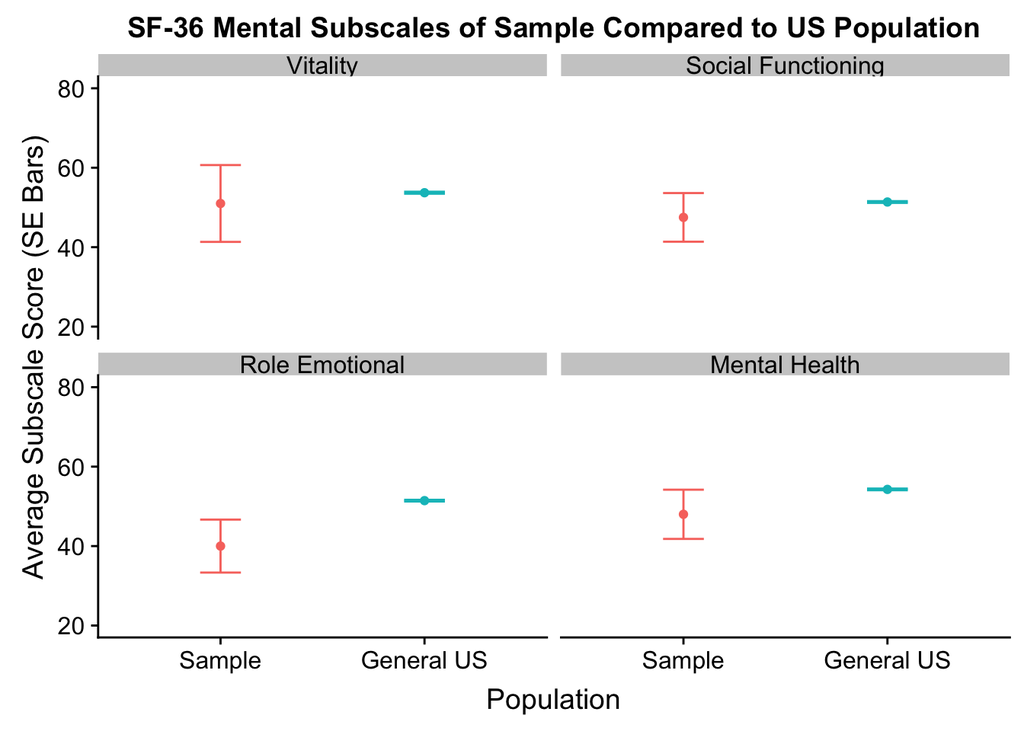

# References

[SF-36](https://www.rand.org/health/surveys_tools/mos/36-item-short-form/survey-instrument.html) by RAND  
[Google Drive Folder](https://drive.google.com/drive/folders/1W7OvdZls7Y52vpiyQKPgF1YVjpXtSNPd?usp=sharing) containing SF-36 Form and Sheet Output  
[Commentaries encouraging the use of Google Forms in health and social sciences](https://www.ncbi.nlm.nih.gov/pmc/articles/PMC3884902/)  
[readxl](https://www.rdocumentation.org/packages/readxl/versions/0.1.1) package  
SF-36 [Scoring Instructions](https://www.rand.org/health/surveys_tools/mos/36-item-short-form/scoring.html) by RAND  
SF-36 Scoring Program in [SAS](https://www.rand.org/pubs/drafts/DRU1437.html) by Ron Hayes  
SF-36 Scoring Program in [Word](https://cours.etsmtl.ca/gts813/documents/sf36_scoring_system.doc)  
[Australian Longitudinal Study on Women’s Health](https://www.alswh.org.au/)  
[Calculating physical and mental composite scores of SF-36](http://www.alswh.org.au/images/content/pdf/InfoData/Data_Dictionary_Supplement/DDSSection2SF36.pdf)  
[Standardize SF-36 scores to the general US population](https://www.ncbi.nlm.nih.gov/pmc/articles/PMC3582698/)